# Practical Machine Learning Course Project

Saurabh Kesarwani

March 8, 2017

This project is part of Johns Hopkins University’s Practical Machine Learning MOOC on Coursera.

## Project Background

Using devices such as Jawbone Up, Nike FuelBand, and Fitbit it is now possible to collect a large amount of data about personal activity relatively inexpensively. These type of devices are part of the quantified self movement – a group of enthusiasts who take measurements about themselves regularly to improve their health, to find patterns in their behavior, or because they are tech geeks. One thing that people regularly do is quantify how much of a particular activity they do, but they rarely quantify how well they do it. In this project, our goal will be to use data from accelerometers on the belt, forearm, arm, and dumbell of 6 participants. They were asked to perform barbell lifts correctly and incorrectly in 5 different ways.

This project is an analysis of Human Activity Recognition exercises and the training of data models to predict the ‘classe’ outcome which indicates whether an individual corrrectly performed an exercise (value of ‘A’) or incorrectly performed it in one of four alternative ways (value of ‘B’, ‘C’, ‘D’, or ‘E’).

## Goal

The goal of this project is to predict the manner in which user groups did the exercise. This is the “classe” variable in the training set. We may use any of the other variables to predict with. We should create a report describing how we built the model, how we used cross validation, what we think the expected out of sample error is, and why we made the choices we did. We will also use our prediction model to predict 20 different test cases.

## Importing Data

The training and test data set has been provided as csv files, which needs to be imported into R for further processing.

```r
urltraining <- "https://d396qusza40orc.cloudfront.net/predmachlearn/pml-training.csv"
urltesting <- "https://d396qusza40orc.cloudfront.net/predmachlearn/pml-testing.csv"

training <- read.csv(url(urltraining), na.strings = c("NA", "#DIV/0!", ""))
testing <- read.csv(url(urltesting), na.strings = c("NA", "#DIV/0!", ""))
```

We take care to convert all blank spaces and divide by zero errors to NA while importing so as to avoid computational issues later on.

## Data Cleaning

```r
dim(training); dim(testing)
```

```
## [1] 19622   160
```

```
## [1]  20 160
```

Having a look at the imported data we see that there are 160 columns present.

#### 1. Removing NA’s

As most of the columns are having NA as observations, We will remove the columns which have NA in them.

```r
training_na <- training[, colSums(is.na(training)) < 1]
testing_na <- testing[, colSums(is.na(testing))< 1]
dim(training_na); dim(testing_na)
```

```
## [1] 19622    60
```

```
## [1] 20 60
```

The number of columns have nowbeen redeuced to 60 from 160.

#### 2. Removing Near Zero Variables

Next we will find and remove all the Near Zero Variables from our data as they are less meaningful predictors and can be removed from prediction algorithms.

```r
library(caret)
nzv <- nearZeroVar(training_na, saveMetrics = TRUE)
training_nzv <- training_na[,nzv$nzv==FALSE]

nzv <- nearZeroVar(testing_na, saveMetrics = TRUE)
testing_nzv <- testing_na[,nzv$nzv==FALSE]
dim(training_nzv); dim(testing_nzv)
```

```
## [1] 19622    59
```

```
## [1] 20 59
```

One nzv variable gets reduced from the dataset.

#### 3. Removing first five columns

We can see that the first five column only contains row numbers, username and timestamps thus can be removed as these do not have much prediction value.

```r
train_clean <- training_nzv[,-(1:5)]
test_clean <- testing_nzv[,-(1:5)]
# Removing the dependent variable classe from test set
test_final <- test_clean[,-54]
dim(train_clean); dim(test_final)
```

```
## [1] 19622    54
```

```
## [1] 20 53
```

## Data Splitting

Training data will be split in 60:40 ratio between Training:Validation sets.The validation set would be used to test few prediction models and find which one gives the best result. Best performing model would then be applied on the test data set.

```r
inTrain <- createDataPartition(train_clean$classe, p = 0.6, list = FALSE)
train <- train_clean[inTrain,]
valid <- train_clean[-inTrain,]
```

## Training Prediction Models

### 1. Generalised Boosted Regression Model

As this is a classification problem we want to try GBM which gives good accuracy and low out-of-sample error rate.

GBM is being trained with repeated cross validation resampling using 3 folds, instead of the default vaule of k=10, to save on computational time.

```r
fitControl_gbm <- trainControl(method = "repeatedcv", number=3, repeats = 1)
time_gbm <- system.time(
                         mod_gbm <- train(classe ~ ., data=train, method= "gbm",
                                       trControl=fitControl_gbm, verbose = FALSE)
                       );
mod_gbm
```

```
## Stochastic Gradient Boosting
##
## 11776 samples
##    53 predictor
##     5 classes: 'A', 'B', 'C', 'D', 'E'
##
## No pre-processing
## Resampling: Cross-Validated (3 fold, repeated 1 times)
## Summary of sample sizes: 7851, 7850, 7851
## Resampling results across tuning parameters:
##
##   interaction.depth  n.trees  Accuracy   Kappa
##   1                   50      0.7615490  0.6976735
##   1                  100      0.8328803  0.7885548
##   1                  150      0.8704992  0.8361068
##   2                   50      0.8833226  0.8522681
##   2                  100      0.9367362  0.9199398
##   2                  150      0.9618720  0.9517498
##   3                   50      0.9315561  0.9133304
##   3                  100      0.9699391  0.9619612
##   3                  150      0.9832712  0.9788364
##
## Tuning parameter 'shrinkage' was held constant at a value of 0.1
##
## Tuning parameter 'n.minobsinnode' was held constant at a value of 10
## Accuracy was used to select the optimal model using  the largest value.
## The final values used for the model were n.trees = 150,
##  interaction.depth = 3, shrinkage = 0.1 and n.minobsinnode = 10.
```

The time GBM took for training was 333.66 seconds

From the following plot we can see how the GBM model works to increase its prediction accuracy through several boosted iteration.

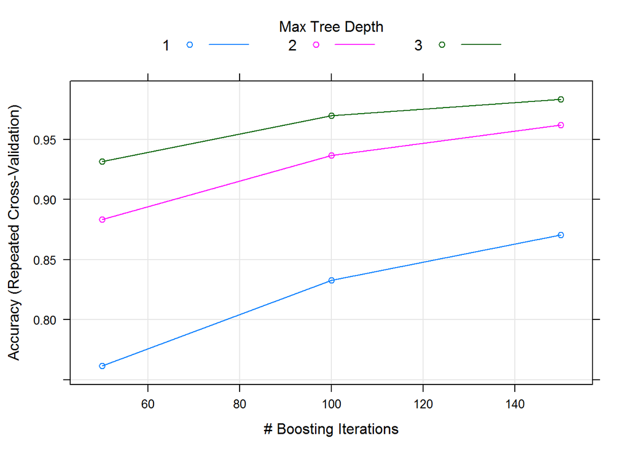

```r
plot(mod_gbm)
```

Now performing the prediction with GBM.

```r
#predict outcomes using validation set
pred_gbm <- predict(mod_gbm,valid)
accuracy_gbm <- confusionMatrix(valid$classe, pred_gbm)$overall[1]
accuracy_gbm
```

```
##  Accuracy
## 0.9847056
```

We have receive an Accuracy of 0.9847056 for Generalised Boosted Model. Here the out-of-sample error rate is 0.0152944.

### 2. Random Forest

Second model being used is Random Forest which is also know for having low out-of-sample error rate and preferred for classification type prediction.

```r
# instruct train to use 3-fold CV to select optimal tuning parameters

fitControl_rf <- trainControl(method="cv", number=3, verboseIter=F)
time_rf <- system.time(
              mod_rf <- train(classe ~ ., data=train, method="rf", trControl=fitControl_rf)
            );
mod_rf
```

```
## Random Forest
##
## 11776 samples
##    53 predictor
##     5 classes: 'A', 'B', 'C', 'D', 'E'
##
## No pre-processing
## Resampling: Cross-Validated (3 fold)
## Summary of sample sizes: 7850, 7851, 7851
## Resampling results across tuning parameters:
##
##   mtry  Accuracy   Kappa
##    2    0.9892153  0.9863559
##   27    0.9958390  0.9947367
##   53    0.9937160  0.9920502
##
## Accuracy was used to select the optimal model using  the largest value.
## The final value used for the model was mtry = 27.
```

The time RF model took for training was 777.79 seconds

On plotting for RF we see that accuracy is determined very differenctly as compared with GBM.

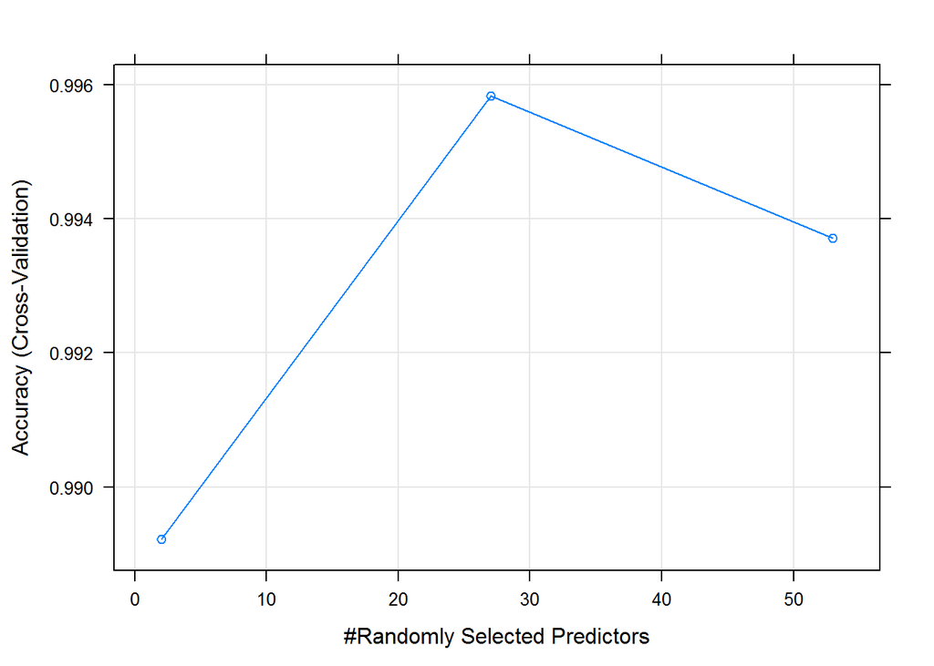

```r
plot(mod_rf)
```

Now performing the prediction with Random Forest.

```r
#predict outcomes using validation set
pred_rf <- predict(mod_rf,valid)
accuracy_rf <- confusionMatrix(valid$classe, pred_rf)$overall[1]
accuracy_rf
```

```
## Accuracy
## 0.997196
```

We receive Accuracy of 0.997196 and the out-of-sample error rate is 0.002804for Random Forest. As we have received prediction accuracy which is higher than that of GBM and lower out-of-sample error rate, thus we will use Random Forest for prediction on test set.

## Predicting on Testing Set

We will use random forests to predict the outcome of variable classe on the testing set.

```r
(predict(mod_rf, test_final))
```

```
##  [1] B A B A A E D B A A B C B A E E A B B B
## Levels: A B C D E
```

## Conclusion

The prediction accuracy of Random Forest was found to be only 1.25% higher than that of Generalised Boosted Model but the time taken to complete training was far much lower for GBM. Between these two models there is no hands down winner as both have given similar results and one needs to trade-off between Accuracy and Processing time to decide in between the two.